# Ch 1 Problem Set

theBudgetActuary

[Link for Solutions In Video Format](https://youtu.be/qBI3p8bxBlU)

# Questions:

## True or FALSE

1. As the flexibility of a model increases, we can expect the **test** MSE to continuously decrease.
2. We train our models or functions on the train data, and get realistic accuracy measurements by applying our models to unseen data, known as the test set.
3. As variance rises so does the squared bias.
4. The most interpretable models are also the most accurate.
5. Since the $\epsilon$ term in **Y = f(x) + $\epsilon$** has a mean of 0 it does not affect the prediction accuracy.
6. As the flexibility of our model increase the error term, $\epsilon$, will decrease as the model better fits the data.
7. The unbiased sample variance, $S_{x}^2$, will always be at least as big as the population variance.
8. A nominal variable has some kind of ordering to its possible outcomes, such as hot, mild, or cold.
9. Unsupervised means we have no dependent variable.
10. A box plot gives a 5 number summary of a variable.
11. A scatterplot is a univariate plot that shows a variables distribution.
12. When testing if a variable follows a distribution besides normal, we can still use a qq-plot.
13. If there is a larger range between the median and 25th percentile than the median and 75th percentile, we can expect the variable to be skewed to the left.

## Math:

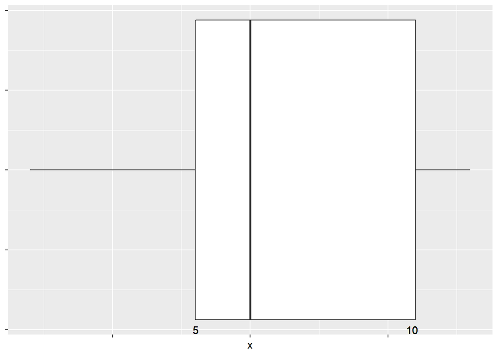

#### **1)**

Based off the boxplot above, what is the IQR?

#### **2)**

What is the range of values where the variable x is not an outlier.

#### **3)**

From the data below, what is the unbiased sample variance of y, $S_{y}^2$ and what is the correlation between x and y?

| x | y |
| --- | --- |
| 2 | 6 |
| 5 | 8 |
| 5 | 1 |

#### **4)**

You are told to use Bayes Classifier to guess whether an animal is a cat, bear, or dog based off their weight and ear size. You are given the probabilities of a cat and a dog.

*Cat Probability*

```
##       large small
## heavy   0.0   0.1
## light   0.3   0.9
```

*Dog probability*

```
##       large small
## heavy   0.3   0.4
## light   0.7   0.1
```

What is the Bayes Classifier error rate?

#### **5)**

You are given a response variable and the predictions for that response variable.

| predicted | observed |
| --- | --- |
| 1 | 2 |
| 4 | 4 |
| 3 | 5 |
| 5 | 7 |

What is the MSE?

# Solutions:

## True or False

1. False: As the flexibility increases the train MSE continuously decreases. The test MSE generally decreases as squared bias decreases faster than variance rises. At a point the variance begins to rise faster than the squared bias decreases causing test MSE to increase.
2. True
3. False: As variance rises the squared bias decreases and vice versa.
4. False: As accuracy rises interpretability decreases.
5. False: Since the variance of $\epsilon$ is not 0 and we know variance affects the test MSE, then $\epsilon$ has an affect on accuracy.
6. False: $\epsilon$ is not affected by the model chosen.
7. True: Sample variance divides by n-1 while population variance divides by n. As n increases the sample variance will approach the population variance.
8. False: Nominal means no order. Ordinal means ordered.
9. True
10. True
11. False: Univariate means one variable plot, a scatterplot compares two variables.
12. True: A qqplot can test for other distributions besides normal. Same rule of following a straight line proves it follows that distribution.
13. True: If box is larger left of median than skewed to the left.

## Math Solutions:

#### **1)**

IQR = $75^{th}$ - $25^{th}$ percentile

IQR = 10-5 = **5**

#### **2)**

Upper Whisker: $75^{th}$+(1.5)*IQR = 10+(1.5)(5) = 17.5

Lower Whisker: $25^{th}$-(1.5)*IQR = 5-(1.5)(5) = -2.5

**-2.5 $\le$ x $\le$ 17.5** is not an outlier

#### **3)**

$S_{y}^2$ = $\frac{\sum (y_{i} - \bar{y})^{2}}{n-1}$ = $\frac{(6-5)^{2} + (8-5)^{2} + (1-5)^{2}}{3-1}$ = **13**

$r_{x,y}$ = $\frac{\sum_{i=1}^{n}(x_{i}-\bar{x})(y_{i}-\bar{y})}{\sqrt{\sum_{i=1}^{n}(x_{i}-\bar{x})^2\sum_{i=1}^{n}(y_{i}-\bar{y})^2}}$ = **-.2402**

#### **4)**

Bayes Classifier: $1-E\big(\underset{j}{max}Pr(Y=j|X)\big)$

$1-\frac{.7+.5+.7+.9}{4}$ = **.3**

#### **5)**

MSE: $\frac{1}{n}\sum_{i=1}^{n}(y_{i}-\hat{f}(x_{i}))^2$

$\frac{(2-1)^2 + (4-4)^2 + (5-3)^2 + (7-5)^2}{4}=$ **2.25**